# Lab07 — Integrador para Alunos (v1)

Author

Ricardo Ceneviva

Published

March 30, 2026

# 1 Título e abertura

Este documento integra, em formato didático, os resultados já validados do Lab07.

**Classificação da Subfase 3:**

- modo principal: produção pedagógica;
- modo secundário: integração de materiais;
- modo subordinado: apoio empírico somente por leitura de artefatos já existentes.

Este material foi organizado para distribuição aos alunos, preservando as decisões metodológicas já aprovadas nas fases anteriores.

# 2 Objetivo de aprendizagem

Ao final deste laboratório, espera-se que a turma consiga:

1. distinguir associação (OLS) de interpretação causal (IV/2SLS);
2. explicar a lógica do instrumento climático no artigo de Miguel, Satyanath e Sergenti (2004);
3. interpretar resultados de first stage, reduced form e IV sem reestimar modelos;
4. discutir limitações de identificação com base nos diagnósticos já validados.

# 3 Pergunta causal e contexto empírico

A pergunta causal central é:

> Qual é o efeito de choques de crescimento econômico sobre a probabilidade de conflito civil?

No desenho do artigo original e do Lab07:

- a variável de interesse é o crescimento econômico;
- o desfecho é conflito civil em painel país-ano;
- a estratégia causal usa choques de chuva como instrumento para crescimento.

Intuição do IV:

1. **Relevância:** chuva afeta crescimento em economias com forte dependência agrícola.
2. **Exogeneidade condicional:** choques de chuva são tratados como variação exógena para identificar o componente de crescimento não determinado por conflito.
3. **Canal causal estimado:** chuva $\rightarrow$ crescimento $\rightarrow$ conflito.

Este integrador preserva a interpretação validada nas fases anteriores e não modifica resultados.

Guia de leitura: os blocos seguintes caminham da descrição do painel para benchmarks OLS, depois para identificação IV e, por fim, para comparação crítica dos resultados.

# 4 Instruções de execução

## 4.1 Convenção de execução e caminhos

- Arquivo-fonte canônico: `docs/lab07_integrador_alunos_v1.qmd`.
- Output principal canônico: `docs/lab07_integrador_alunos_v1.html`.
- Formato principal: HTML.
- Formato opcional futuro: PDF (não implementado nesta subfase).
- Caminhos sempre relativos à raiz do projeto.
- Integração com R via Quarto/knitr.

## 4.2 Regra central de não interferência

1. Este integrador **não** reestima modelos do Lab07.
2. Este integrador **não** sobrescreve outputs das Fases 3A–3E.
3. Este integrador **não** modifica dados em `Data/`.
4. Este integrador **não** substitui pipeline validado.
5. Nesta subfase, blocos de código com risco de reestimação devem ficar com `eval: false`.

## 4.3 Convenções de chunks, tabelas e figuras

- Padrão de nomes de chunks:
  - setup: `sf2-setup-*`
  - blocos analíticos: `b1-*`, `b2-*`, …, `b6-*`
  - tabelas: `tbl-*`
  - figuras: `fig-*`
- Política de execução nesta subfase:
  - `echo: true` por padrão didático;
  - `warning: false` e `message: false` para legibilidade;
  - `eval: false` em qualquer chunk que possa alterar resultados já validados.
- Política de IO:
  - leitura de artefatos apenas em `outputs/` com caminhos relativos;
  - proibição de escrita/sobrescrita de arquivos existentes.
- Legendas e rótulos:
  - tabelas futuras com prefixo `tbl:` e rótulo `#tbl-*`;
  - figuras futuras com prefixo `fig:` e rótulo `#fig-*`.
- Referências cruzadas futuras:
  - usar `@tbl-*` e `@fig-*` para manter rastreabilidade didática.

```r
# Setup de leitura e exibição (sem estimação).
library(readr)
library(dplyr)
library(knitr)

knitr::opts_chunk$set(
  echo = TRUE,
  warning = FALSE,
  message = FALSE
)

# O arquivo .qmd está em docs/; a raiz analítica do projeto está um nível acima.
knitr::opts_knit$set(root.dir = "..")
```

# 5 Bloco 1: Problema causal e desenho

Este bloco organiza a lógica do problema causal.

- Se usarmos apenas OLS, o coeficiente de crescimento pode capturar causalidade reversa e variáveis omitidas.
- A estratégia IV busca isolar a parte exógena do crescimento gerada por choques climáticos.
- Assim, a leitura causal recai sobre o componente identificado pelo instrumento, e não sobre qualquer variação observada de crescimento.

Checkpoint conceitual:

1. O que precisa ser verdadeiro para interpretar IV como causal?
2. Por que OLS e IV podem diferir em magnitude?

# 6 Bloco 2: Estrutura dos dados

Neste bloco, descrevemos a estrutura do painel a partir da tabela descritiva validada na Fase 3B.

```r
tbl_b2_desc <- readr::read_csv("outputs/lab07_phase3b_descriptive_stats.csv", show_col_types = FALSE)
tbl_b2_desc
```

```
# A tibble: 13 × 6
   variavel    media desvio_padrao   minimo maximo     N
   <chr>       <dbl>         <dbl>    <dbl>  <dbl> <dbl>
 1 any_prio  0.268          0.443    0       1       743
 2 war_prio  0.167          0.373    0       1       743
 3 gdp_g    -0.00475        0.0707  -0.474   0.670   743
 4 gdp_g_l  -0.00555        0.0724  -0.474   0.670   743
 5 gpcp_g    0.0182         0.209   -0.550   1.68    743
 6 gpcp_g_l  0.0113         0.207   -0.550   1.68    743
 7 y_0       1.16           0.901    0.316   4.84    743
 8 polity2l -3.61           5.55   -10       9       743
 9 ethfrac   0.655          0.237    0.0355  0.925   743
10 relfrac   0.487          0.186    0       0.783   743
11 oil       0.118          0.323    0       1       743
12 lmtnest   1.58           1.43     0       4.42    743
13 lpopl1    8.75           1.21     5.72   11.7     743
```

```r
knitr::kable(
  tbl_b2_desc
)
```

Table 1: Estatísticas descritivas validadas (Fase 3B).

| variavel | media | desvio_padrao | minimo | maximo | N |
| --- | --- | --- | --- | --- | --- |
| any_prio | 0.2678331 | 0.4431284 | 0.0000000 | 1.0000000 | 743 |
| war_prio | 0.1668910 | 0.3731297 | 0.0000000 | 1.0000000 | 743 |
| gdp_g | -0.0047543 | 0.0706980 | -0.4739726 | 0.6704121 | 743 |
| gdp_g_l | -0.0055523 | 0.0723910 | -0.4739726 | 0.6704121 | 743 |
| gpcp_g | 0.0181953 | 0.2094129 | -0.5498713 | 1.6769756 | 743 |
| gpcp_g_l | 0.0112713 | 0.2066666 | -0.5498713 | 1.6769756 | 743 |
| y_0 | 1.1638546 | 0.9009275 | 0.3160000 | 4.8420000 | 743 |
| polity2l | -3.6083445 | 5.5543175 | -10.0000000 | 9.0000000 | 743 |
| ethfrac | 0.6546309 | 0.2373880 | 0.0355107 | 0.9250348 | 743 |
| relfrac | 0.4867532 | 0.1857149 | 0.0000000 | 0.7828000 | 743 |
| oil | 0.1184388 | 0.3233446 | 0.0000000 | 1.0000000 | 743 |
| lmtnest | 1.5783078 | 1.4333633 | 0.0000000 | 4.4212475 | 743 |
| lpopl1 | 8.7496653 | 1.2068426 | 5.7170277 | 11.7056694 | 743 |

Leitura didática:

- A estrutura é país-ano (painel), com variáveis de conflito, crescimento e controles.
- O N da amostra validada é mantido conforme pipeline já encerrado.
- Nesta subfase, os dados são apenas lidos de `outputs/`.

Para consulta rápida, a Tabela Table 1 resume as variáveis centrais usadas no restante do integrador.

# 7 Bloco 3: Benchmark OLS

Este bloco apresenta os benchmarks OLS como **associação**, não como efeito causal.

```r
tbl_b3_ols_simple <- readr::read_csv("outputs/lab07_phase3c_ols_simple_tidy.csv", show_col_types = FALSE)
tbl_b3_ols_full <- readr::read_csv("outputs/lab07_phase3c_ols_full_tidy.csv", show_col_types = FALSE)

tbl_b3_ols_simple
```

```
# A tibble: 3 × 7
  term        estimate std.error statistic    p.value conf.low conf.high
  <chr>          <dbl>     <dbl>     <dbl>      <dbl>    <dbl>     <dbl>
1 (Intercept)   0.266     0.0520     5.12  0.00000809    0.161     0.371
2 gdp_g        -0.309     0.275     -1.12  0.268        -0.866     0.247
3 gdp_g_l      -0.0727    0.253     -0.287 0.776        -0.584     0.439
```

```r
tbl_b3_ols_full
```

```
# A tibble: 5 × 7
  term      estimate std.error statistic p.value conf.low conf.high
  <chr>        <dbl>     <dbl>     <dbl>   <dbl>    <dbl>     <dbl>
1 gdp_g    -0.174      0.144     -1.20     0.236 -0.465     0.118
2 gdp_g_l   0.0992     0.168      0.589    0.559 -0.241     0.439
3 polity2l  0.000350   0.00440    0.0796   0.937 -0.00853   0.00923
4 oil       0.0680     0.0441     1.54     0.131 -0.0212    0.157
5 lpopl1    0.806      0.708      1.14     0.262 -0.625     2.24
```

```r
knitr::kable(
  tbl_b3_ols_simple
)
```

Table 2: OLS simples (benchmark associativo) — resultados validados na Fase 3C.

| term | estimate | std.error | statistic | p.value | conf.low | conf.high |
| --- | --- | --- | --- | --- | --- | --- |
| (Intercept) | 0.2659587 | 0.0519509 | 5.1194255 | 0.0000081 | 0.1609620 | 0.3709553 |
| gdp_g | -0.3094018 | 0.2753101 | -1.1238303 | 0.2677846 | -0.8658243 | 0.2470206 |
| gdp_g_l | -0.0726641 | 0.2530957 | -0.2871012 | 0.7755169 | -0.5841895 | 0.4388614 |

```r
knitr::kable(
  tbl_b3_ols_full
)
```

Table 3: OLS ampliado com controles — resultados validados na Fase 3C.

| term | estimate | std.error | statistic | p.value | conf.low | conf.high |
| --- | --- | --- | --- | --- | --- | --- |
| gdp_g | -0.1737422 | 0.1442535 | -1.2044228 | 0.2355046 | -0.4652895 | 0.1178050 |
| gdp_g_l | 0.0991578 | 0.1682599 | 0.5893135 | 0.5589650 | -0.2409081 | 0.4392237 |
| polity2l | 0.0003500 | 0.0043959 | 0.0796268 | 0.9369312 | -0.0085345 | 0.0092346 |
| oil | 0.0679601 | 0.0441166 | 1.5404646 | 0.1313217 | -0.0212029 | 0.1571232 |
| lpopl1 | 0.8055131 | 0.7076884 | 1.1382313 | 0.2617956 | -0.6247785 | 2.2358047 |

Interpretação didática:

- OLS informa covariação entre crescimento e conflito.
- Sem identificação exógena, o coeficiente não deve ser lido como causal.
- OLS funciona como benchmark para comparação com IV.

As Tabelas Table 2 e Table 3 devem ser lidas como referência associativa para o contraste posterior com IV.

Checkpoint conceitual (Bloco 3):

1. Qual é a diferença entre “coeficiente estatisticamente diferente de zero” e “efeito causal identificado”?
2. Por que controles observáveis não eliminam, por si só, toda endogeneidade?

# 8 Bloco 4: First stage e reduced form

Este bloco verifica a etapa intermediária de identificação IV.

```r
tbl_b4_fs_diag <- readr::read_csv("outputs/lab07_phase3d_first_stage_diagnostics.csv", show_col_types = FALSE)
tbl_b4_rf <- readr::read_csv("outputs/lab07_phase3d_reduced_form_tidy.csv", show_col_types = FALSE)

tbl_b4_fs_diag
```

```
# A tibble: 3 × 5
  diagnostico   estatistica p_value gl_num gl_den
  <chr>               <dbl>   <dbl>  <dbl>  <dbl>
1 ivf1::gdp_g          6.40 0.00176      2    696
2 ivf1::gdp_g_l        5.14 0.00609      2    696
3 ivf2                 2.87 0.0573       2    696
```

```r
tbl_b4_rf
```

```
# A tibble: 5 × 7
  term      estimate std.error statistic p.value conf.low conf.high
  <chr>        <dbl>     <dbl>     <dbl>   <dbl>    <dbl>     <dbl>
1 gpcp_g   -0.0206     0.0420     -0.491  0.626  -0.106     0.0643
2 gpcp_g_l -0.114      0.0505     -2.26   0.0296 -0.216    -0.0118
3 polity2l  0.000468   0.00446     0.105  0.917  -0.00855   0.00948
4 oil       0.0686     0.0371      1.85   0.0717 -0.00633   0.144
5 lpopl1    0.755      0.703       1.07   0.289  -0.666     2.18
```

```r
knitr::kable(
  tbl_b4_fs_diag
)
```

Table 4: Diagnósticos de first stage (Fase 3D).

| diagnostico | estatistica | p_value | gl_num | gl_den |
| --- | --- | --- | --- | --- |
| ivf1::gdp_g | 6.399485 | 0.0017619 | 2 | 696 |
| ivf1::gdp_g_l | 5.138218 | 0.0060928 | 2 | 696 |
| ivf2 | 2.870927 | 0.0573175 | 2 | 696 |

```r
knitr::kable(
  tbl_b4_rf
)
```

Table 5: Reduced form validado na Fase 3D.

| term | estimate | std.error | statistic | p.value | conf.low | conf.high |
| --- | --- | --- | --- | --- | --- | --- |
| gpcp_g | -0.0206457 | 0.0420299 | -0.4912146 | 0.6259592 | -0.1055912 | 0.0642998 |
| gpcp_g_l | -0.1138222 | 0.0504638 | -2.2555238 | 0.0296402 | -0.2158133 | -0.0118312 |
| polity2l | 0.0004680 | 0.0044614 | 0.1049036 | 0.9169766 | -0.0085488 | 0.0094849 |
| oil | 0.0685875 | 0.0370683 | 1.8502977 | 0.0716668 | -0.0063304 | 0.1435054 |
| lpopl1 | 0.7553049 | 0.7029978 | 1.0744058 | 0.2890795 | -0.6655067 | 2.1761164 |

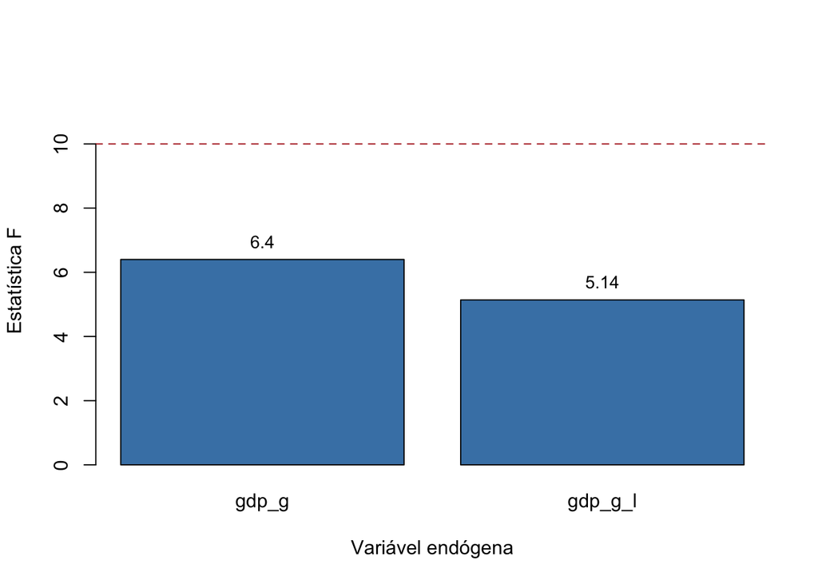

Figure 1: Estatísticas F do first stage para as variáveis endógenas (Fase 3D).

```r
plot_df_fs <- tbl_b4_fs_diag |>
  dplyr::filter(diagnostico %in% c("ivf1::gdp_g", "ivf1::gdp_g_l")) |>
  dplyr::mutate(
    diagnostico = dplyr::recode(
      diagnostico,
      "ivf1::gdp_g" = "gdp_g",
      "ivf1::gdp_g_l" = "gdp_g_l"
    )
  )

bar_centers <- barplot(
  height = plot_df_fs$estatistica,
  names.arg = plot_df_fs$diagnostico,
  col = "steelblue",
  ylim = c(0, max(10, plot_df_fs$estatistica) * 1.15),
  ylab = "Estatística F",
  xlab = "Variável endógena"
)
abline(h = 10, lty = 2, col = "firebrick")
text(
  x = bar_centers,
  y = plot_df_fs$estatistica,
  labels = round(plot_df_fs$estatistica, 2),
  pos = 3,
  cex = 0.9
)
```

Interpretação didática:

- A relevância do instrumento é avaliada pelos diagnósticos do first stage.
- No material validado, os F-stat principais são menores que 10, indicando instrumento de força moderada/fraca.
- Isso não invalida automaticamente a análise, mas exige cautela na interpretação causal.

A Tabela Table 4 e a Figura Figure 1 sintetizam essa etapa de diagnóstico.

Checkpoint conceitual (Bloco 4):

1. O que a condição de relevância exige do first stage?
2. Por que $F < 10$ aumenta a preocupação com precisão e viés finito em IV?

# 9 Bloco 5: 2SLS

Este bloco reporta os coeficientes IV principais já validados na Fase 3D.

```r
tbl_b5_iv <- readr::read_csv("outputs/lab07_phase3d_iv_main_tidy.csv", show_col_types = FALSE)
tbl_b5_iv
```

```
# A tibble: 5 × 7
  term        estimate std.error statistic p.value conf.low conf.high
  <chr>          <dbl>     <dbl>     <dbl>   <dbl>    <dbl>     <dbl>
1 fit_gdp_g   -1.15      1.46       -0.789  0.435   -4.10     1.80
2 fit_gdp_g_l -2.62      1.23       -2.13   0.0391  -5.10    -0.137
3 polity2l    -0.00161   0.00551    -0.292  0.772   -0.0127   0.00952
4 oil         -0.0972    0.125      -0.778  0.441   -0.350    0.155
5 lpopl1      -0.317     1.14       -0.279  0.781   -2.61     1.98
```

```r
knitr::kable(
  tbl_b5_iv
)
```

Table 6: Resultados IV/2SLS principais (Fase 3D).

| term | estimate | std.error | statistic | p.value | conf.low | conf.high |
| --- | --- | --- | --- | --- | --- | --- |
| fit_gdp_g | -1.1512613 | 1.4590559 | -0.7890453 | 0.4347376 | -4.1001233 | 1.7976008 |
| fit_gdp_g_l | -2.6190974 | 1.2279808 | -2.1328488 | 0.0391253 | -5.1009391 | -0.1372556 |
| polity2l | -0.0016071 | 0.0055079 | -0.2917718 | 0.7719690 | -0.0127390 | 0.0095248 |
| oil | -0.0972105 | 0.1250113 | -0.7776138 | 0.4413719 | -0.3498676 | 0.1554467 |
| lpopl1 | -0.3174685 | 1.1361369 | -0.2794281 | 0.7813561 | -2.6136869 | 1.9787498 |

Interpretação didática:

- O estimando IV é interpretado como **LATE** (efeito causal local) para a variação de crescimento induzida pelo instrumento.
- A leitura causal vale sob as hipóteses de identificação discutidas no Bloco 1.
- Em presença de first stage moderado, a incerteza estatística deve ser enfatizada.

Na prática, a Tabela Table 6 deve ser lida junto aos diagnósticos do Bloco 4.

Checkpoint conceitual (Bloco 5):

1. Em que sentido o IV identifica um efeito local (LATE), e não necessariamente um efeito médio global?
2. Como interpretar sinal e magnitude quando o erro padrão é elevado?

# 10 Bloco 6: Interpretação e crítica

Este bloco integra comparação entre modelos e limitações.

```r
tbl_b6_comp_3d <- readr::read_csv("outputs/lab07_phase3d_models_comparison_tidy.csv", show_col_types = FALSE)
tbl_b6_comp_3e <- readr::read_csv("outputs/lab07_phase3e_final_models_comparison.csv", show_col_types = FALSE)

tbl_b6_comp_3d
```

```
# A tibble: 18 × 8
   modelo          term  estimate std.error statistic p.value conf.low conf.high
   <chr>           <chr>    <dbl>     <dbl>     <dbl>   <dbl>    <dbl>     <dbl>
 1 mod_ols_simple… (Int…  2.66e-1   0.0520     5.12   8.09e-6  0.161     0.371
 2 mod_ols_simple… gdp_g -3.09e-1   0.275     -1.12   2.68e-1 -0.866     0.247
 3 mod_ols_simple… gdp_… -7.27e-2   0.253     -0.287  7.76e-1 -0.584     0.439
 4 mod_ols_full (… gdp_g -1.74e-1   0.144     -1.20   2.36e-1 -0.465     0.118
 5 mod_ols_full (… gdp_…  9.92e-2   0.168      0.589  5.59e-1 -0.241     0.439
 6 mod_ols_full (… poli…  3.50e-4   0.00440    0.0796 9.37e-1 -0.00853   0.00923
 7 mod_ols_full (… oil    6.80e-2   0.0441     1.54   1.31e-1 -0.0212    0.157
 8 mod_ols_full (… lpop…  8.06e-1   0.708      1.14   2.62e-1 -0.625     2.24
 9 mod_rf_main (r… gpcp… -2.06e-2   0.0420    -0.491  6.26e-1 -0.106     0.0643
10 mod_rf_main (r… gpcp… -1.14e-1   0.0505    -2.26   2.96e-2 -0.216    -0.0118
11 mod_rf_main (r… poli…  4.68e-4   0.00446    0.105  9.17e-1 -0.00855   0.00948
12 mod_rf_main (r… oil    6.86e-2   0.0371     1.85   7.17e-2 -0.00633   0.144
13 mod_rf_main (r… lpop…  7.55e-1   0.703      1.07   2.89e-1 -0.666     2.18
14 mod_iv_main (s… fit_… -1.15e+0   1.46      -0.789  4.35e-1 -4.10      1.80
15 mod_iv_main (s… fit_… -2.62e+0   1.23      -2.13   3.91e-2 -5.10     -0.137
16 mod_iv_main (s… poli… -1.61e-3   0.00551   -0.292  7.72e-1 -0.0127    0.00952
17 mod_iv_main (s… oil   -9.72e-2   0.125     -0.778  4.41e-1 -0.350     0.155
18 mod_iv_main (s… lpop… -3.17e-1   1.14      -0.279  7.81e-1 -2.61      1.98
```

```r
tbl_b6_comp_3e
```

```
# A tibble: 33 × 10
   modelo     desfecho tipo  term  estimate std.error statistic p.value conf.low
   <chr>      <chr>    <chr> <chr>    <dbl>     <dbl>     <dbl>   <dbl>    <dbl>
 1 OLS simpl… any_prio OLS   (Int…  2.66e-1   0.0520     5.12   8.09e-6  0.161
 2 OLS simpl… any_prio OLS   gdp_g -3.09e-1   0.275     -1.12   2.68e-1 -0.866
 3 OLS simpl… any_prio OLS   gdp_… -7.27e-2   0.253     -0.287  7.76e-1 -0.584
 4 OLS ampli… any_prio OLS   gdp_g -1.74e-1   0.144     -1.20   2.36e-1 -0.465
 5 OLS ampli… any_prio OLS   gdp_…  9.92e-2   0.168      0.589  5.59e-1 -0.241
 6 OLS ampli… any_prio OLS   poli…  3.50e-4   0.00440    0.0796 9.37e-1 -0.00853
 7 OLS ampli… any_prio OLS   oil    6.80e-2   0.0441     1.54   1.31e-1 -0.0212
 8 OLS ampli… any_prio OLS   lpop…  8.06e-1   0.708      1.14   2.62e-1 -0.625
 9 Reduced f… any_prio RF    gpcp… -2.06e-2   0.0420    -0.491  6.26e-1 -0.106
10 Reduced f… any_prio RF    gpcp… -1.14e-1   0.0505    -2.26   2.96e-2 -0.216
# ℹ 23 more rows
# ℹ 1 more variable: conf.high <dbl>
```

```r
knitr::kable(
  tbl_b6_comp_3d
)
```

Table 7: Comparação de modelos (Fase 3D).

| modelo | term | estimate | std.error | statistic | p.value | conf.low | conf.high |
| --- | --- | --- | --- | --- | --- | --- | --- |
| mod_ols_simple (benchmark associativo) | (Intercept) | 0.2659587 | 0.0519509 | 5.1194255 | 0.0000081 | 0.1609620 | 0.3709553 |
| mod_ols_simple (benchmark associativo) | gdp_g | -0.3094018 | 0.2753101 | -1.1238303 | 0.2677846 | -0.8658243 | 0.2470206 |
| mod_ols_simple (benchmark associativo) | gdp_g_l | -0.0726641 | 0.2530957 | -0.2871012 | 0.7755169 | -0.5841895 | 0.4388614 |
| mod_ols_full (benchmark associativo com controles) | gdp_g | -0.1737422 | 0.1442535 | -1.2044228 | 0.2355046 | -0.4652895 | 0.1178050 |
| mod_ols_full (benchmark associativo com controles) | gdp_g_l | 0.0991578 | 0.1682599 | 0.5893135 | 0.5589650 | -0.2409081 | 0.4392237 |
| mod_ols_full (benchmark associativo com controles) | polity2l | 0.0003500 | 0.0043959 | 0.0796268 | 0.9369312 | -0.0085345 | 0.0092346 |
| mod_ols_full (benchmark associativo com controles) | oil | 0.0679601 | 0.0441166 | 1.5404646 | 0.1313217 | -0.0212029 | 0.1571232 |
| mod_ols_full (benchmark associativo com controles) | lpopl1 | 0.8055131 | 0.7076884 | 1.1382313 | 0.2617956 | -0.6247785 | 2.2358047 |
| mod_rf_main (reduced form) | gpcp_g | -0.0206457 | 0.0420299 | -0.4912146 | 0.6259592 | -0.1055912 | 0.0642998 |
| mod_rf_main (reduced form) | gpcp_g_l | -0.1138222 | 0.0504638 | -2.2555238 | 0.0296402 | -0.2158133 | -0.0118312 |
| mod_rf_main (reduced form) | polity2l | 0.0004680 | 0.0044614 | 0.1049036 | 0.9169766 | -0.0085488 | 0.0094849 |
| mod_rf_main (reduced form) | oil | 0.0685875 | 0.0370683 | 1.8502977 | 0.0716668 | -0.0063304 | 0.1435054 |
| mod_rf_main (reduced form) | lpopl1 | 0.7553049 | 0.7029978 | 1.0744058 | 0.2890795 | -0.6655067 | 2.1761164 |
| mod_iv_main (second stage IV) | fit_gdp_g | -1.1512613 | 1.4590559 | -0.7890453 | 0.4347376 | -4.1001233 | 1.7976008 |
| mod_iv_main (second stage IV) | fit_gdp_g_l | -2.6190974 | 1.2279808 | -2.1328488 | 0.0391253 | -5.1009391 | -0.1372556 |
| mod_iv_main (second stage IV) | polity2l | -0.0016071 | 0.0055079 | -0.2917718 | 0.7719690 | -0.0127390 | 0.0095248 |
| mod_iv_main (second stage IV) | oil | -0.0972105 | 0.1250113 | -0.7776138 | 0.4413719 | -0.3498676 | 0.1554467 |
| mod_iv_main (second stage IV) | lpopl1 | -0.3174685 | 1.1361369 | -0.2794281 | 0.7813561 | -2.6136869 | 1.9787498 |

```r
knitr::kable(
  tbl_b6_comp_3e
)
```

Table 8: Comparação final consolidada (Fase 3E).

| modelo | desfecho | tipo | term | estimate | std.error | statistic | p.value | conf.low | conf.high |
| --- | --- | --- | --- | --- | --- | --- | --- | --- | --- |
| OLS simples (any_prio) | any_prio | OLS | (Intercept) | 0.2659587 | 0.0519509 | 5.1194255 | 0.0000081 | 0.1609620 | 0.3709553 |
| OLS simples (any_prio) | any_prio | OLS | gdp_g | -0.3094018 | 0.2753101 | -1.1238303 | 0.2677846 | -0.8658243 | 0.2470206 |
| OLS simples (any_prio) | any_prio | OLS | gdp_g_l | -0.0726641 | 0.2530957 | -0.2871012 | 0.7755169 | -0.5841895 | 0.4388614 |
| OLS ampliado (any_prio) | any_prio | OLS | gdp_g | -0.1737422 | 0.1442535 | -1.2044228 | 0.2355046 | -0.4652895 | 0.1178050 |
| OLS ampliado (any_prio) | any_prio | OLS | gdp_g_l | 0.0991578 | 0.1682599 | 0.5893135 | 0.5589650 | -0.2409081 | 0.4392237 |
| OLS ampliado (any_prio) | any_prio | OLS | polity2l | 0.0003500 | 0.0043959 | 0.0796268 | 0.9369312 | -0.0085345 | 0.0092346 |
| OLS ampliado (any_prio) | any_prio | OLS | oil | 0.0679601 | 0.0441166 | 1.5404646 | 0.1313217 | -0.0212029 | 0.1571232 |
| OLS ampliado (any_prio) | any_prio | OLS | lpopl1 | 0.8055131 | 0.7076884 | 1.1382313 | 0.2617956 | -0.6247785 | 2.2358047 |
| Reduced form (any_prio) | any_prio | RF | gpcp_g | -0.0206457 | 0.0420299 | -0.4912146 | 0.6259592 | -0.1055912 | 0.0642998 |
| Reduced form (any_prio) | any_prio | RF | gpcp_g_l | -0.1138222 | 0.0504638 | -2.2555238 | 0.0296402 | -0.2158133 | -0.0118312 |
| Reduced form (any_prio) | any_prio | RF | polity2l | 0.0004680 | 0.0044614 | 0.1049036 | 0.9169766 | -0.0085488 | 0.0094849 |
| Reduced form (any_prio) | any_prio | RF | oil | 0.0685875 | 0.0370683 | 1.8502977 | 0.0716668 | -0.0063304 | 0.1435054 |
| Reduced form (any_prio) | any_prio | RF | lpopl1 | 0.7553049 | 0.7029978 | 1.0744058 | 0.2890795 | -0.6655067 | 2.1761164 |
| IV second stage (any_prio) | any_prio | IV | fit_gdp_g | -1.1512613 | 1.4590559 | -0.7890453 | 0.4347376 | -4.1001233 | 1.7976008 |
| IV second stage (any_prio) | any_prio | IV | fit_gdp_g_l | -2.6190974 | 1.2279808 | -2.1328488 | 0.0391253 | -5.1009391 | -0.1372556 |
| IV second stage (any_prio) | any_prio | IV | polity2l | -0.0016071 | 0.0055079 | -0.2917718 | 0.7719690 | -0.0127390 | 0.0095248 |
| IV second stage (any_prio) | any_prio | IV | oil | -0.0972105 | 0.1250113 | -0.7776138 | 0.4413719 | -0.3498676 | 0.1554467 |
| IV second stage (any_prio) | any_prio | IV | lpopl1 | -0.3174685 | 1.1361369 | -0.2794281 | 0.7813561 | -2.6136869 | 1.9787498 |
| IV second stage (war_prio) | war_prio | IV robustez | fit_gdp_g | -1.3751049 | 0.8249810 | -1.6668322 | 0.1033604 | -3.0424537 | 0.2922439 |
| IV second stage (war_prio) | war_prio | IV robustez | fit_gdp_g_l | -0.6920098 | 0.7162905 | -0.9661022 | 0.3397981 | -2.1396868 | 0.7556673 |
| IV second stage (war_prio) | war_prio | IV robustez | polity2l | -0.0013874 | 0.0044698 | -0.3103974 | 0.7578704 | -0.0104211 | 0.0076463 |
| IV second stage (war_prio) | war_prio | IV robustez | oil | -0.0795204 | 0.0700188 | -1.1357015 | 0.2628407 | -0.2210337 | 0.0619928 |
| IV second stage (war_prio) | war_prio | IV robustez | lpopl1 | 0.4955143 | 0.7383444 | 0.6711153 | 0.5060043 | -0.9967355 | 1.9877641 |
| IV narrow (any_prio_nar) | any_prio_nar | IV narrow | fit_gdp_g | -0.8224505 | 1.1769568 | -0.6987942 | 0.4887240 | -3.2011689 | 1.5562679 |
| IV narrow (any_prio_nar) | any_prio_nar | IV narrow | fit_gdp_g_l | -2.3832607 | 1.1684853 | -2.0396154 | 0.0480317 | -4.7448577 | -0.0216638 |
| IV narrow (any_prio_nar) | any_prio_nar | IV narrow | polity2l | -0.0014202 | 0.0052022 | -0.2729947 | 0.7862619 | -0.0119343 | 0.0090939 |
| IV narrow (any_prio_nar) | any_prio_nar | IV narrow | oil | -0.0726728 | 0.1099524 | -0.6609482 | 0.5124346 | -0.2948949 | 0.1495492 |
| IV narrow (any_prio_nar) | any_prio_nar | IV narrow | lpopl1 | 0.4099457 | 1.1887754 | 0.3448471 | 0.7320161 | -1.9926589 | 2.8125504 |
| IV narrow (war_prio_nar) | war_prio_nar | IV narrow | fit_gdp_g | -0.8887509 | 0.5959869 | -1.4912256 | 0.1437471 | -2.0932854 | 0.3157836 |
| IV narrow (war_prio_nar) | war_prio_nar | IV narrow | fit_gdp_g_l | -0.2743811 | 0.6384955 | -0.4297307 | 0.6696978 | -1.5648287 | 1.0160665 |
| IV narrow (war_prio_nar) | war_prio_nar | IV narrow | polity2l | -0.0037221 | 0.0043438 | -0.8568745 | 0.3966189 | -0.0125011 | 0.0050570 |
| IV narrow (war_prio_nar) | war_prio_nar | IV narrow | oil | -0.0567246 | 0.0509974 | -1.1123049 | 0.2726476 | -0.1597942 | 0.0463449 |
| IV narrow (war_prio_nar) | war_prio_nar | IV narrow | lpopl1 | 0.7424857 | 0.5249834 | 1.4143032 | 0.1650099 | -0.3185453 | 1.8035166 |

[figure not shown]

Figure 2: Comparação dos coeficientes de crescimento: OLS vs IV para any_prio (dados da Fase 3E).

```r
plot_df_coef <- tbl_b6_comp_3e |>
  dplyr::filter(desfecho == "any_prio") |>
  dplyr::filter(term %in% c("gdp_g", "gdp_g_l", "fit_gdp_g", "fit_gdp_g_l")) |>
  dplyr::filter(modelo %in% c("OLS simples (any_prio)", "OLS ampliado (any_prio)", "IV second stage (any_prio)")) |>
  dplyr::mutate(
    variavel = dplyr::case_when(
      term %in% c("gdp_g", "fit_gdp_g") ~ "gdp_g",
      term %in% c("gdp_g_l", "fit_gdp_g_l") ~ "gdp_g_l",
      TRUE ~ term
    ),
    modelo_plot = factor(
      modelo,
      levels = c("OLS simples (any_prio)", "OLS ampliado (any_prio)", "IV second stage (any_prio)")
    ),
    y_pos = as.numeric(modelo_plot) + ifelse(variavel == "gdp_g", -0.12, 0.12)
  )

xmin <- min(plot_df_coef$conf.low, na.rm = TRUE)
xmax <- max(plot_df_coef$conf.high, na.rm = TRUE)

plot(
  x = plot_df_coef$estimate,
  y = plot_df_coef$y_pos,
  xlim = c(xmin, xmax),
  yaxt = "n",
  pch = ifelse(plot_df_coef$variavel == "gdp_g", 16, 17),
  col = ifelse(plot_df_coef$variavel == "gdp_g", "navy", "darkorange"),
  xlab = "Coeficiente estimado",
  ylab = "Modelo"
)
axis(2, at = 1:3, labels = levels(plot_df_coef$modelo_plot), las = 1)
segments(
  x0 = plot_df_coef$conf.low,
  y0 = plot_df_coef$y_pos,
  x1 = plot_df_coef$conf.high,
  y1 = plot_df_coef$y_pos,
  col = ifelse(plot_df_coef$variavel == "gdp_g", "navy", "darkorange"),
  lwd = 2
)
abline(v = 0, lty = 2, col = "gray40")
legend(
  "bottomright",
  legend = c("gdp_g", "gdp_g_l"),
  pch = c(16, 17),
  col = c("navy", "darkorange"),
  bty = "n"
)
```

Pontos críticos para discussão:

1. diferença entre OLS (associação) e IV (interpretação causal sob hipóteses);
2. instrumento com força moderada/fraca em parte dos diagnósticos ($F < 10$);
3. restrição de exclusão é substantiva e não testável diretamente;
4. número de clusters (países) é limitado, afetando precisão inferencial.

As Tabelas Table 7 e Table 8, junto da Figura Figure 2, apoiam a comparação final entre estratégias.

Checkpoint conceitual (Bloco 6):

1. Quando a divergência OLS vs IV sugere possível viés no benchmark associativo?
2. Quais limitações permanecem mesmo com estratégia IV?

# 11 Síntese final

Resumo didático da Subfase 3:

- O documento agora reúne, em fluxo único, os outputs centrais das Fases 3B, 3C, 3D e 3E.
- A distinção entre associação e causalidade foi mantida explicitamente.
- Foram adicionados gráficos didáticos de diagnóstico e comparação sem reestimação.
- Nenhum modelo foi reestimado e nenhum output do pipeline validado foi sobrescrito.

# 12 Referências / fontes

- Programa da disciplina: `Ceneviva-2026-MAPP-UFABC.pdf`.
- Fonte primária substantiva: Miguel, Satyanath e Sergenti (2004), `Miguel-etal-2004-paper.pdf`.
- Handoff final da Fase 3E: `docs/lab07_phase3e_handoff_2026-03-27.md`.
- Inventário de arquivos: `docs/files_list.md`.
- Regras operacionais: `AGENTS.md` e `Workflow-Projeto.md`.